# Pilot analysis

Sau-Chin Chen

2022/4/26

In this document we generated the pseudo data and reproduced the analysis summary as the norming study in [Hoeben Mannaert et al. (2021)](https://link.springer.com/article/10.3758/s13421-020-01078-6#Sec4) (p. 131).

## Data sheet structure

- jatosStudyResultId: by-participant unit
- term: by-item unit
- Design: Pictures are the “critical” objects or “fillers”.
- Color_pic: Picture is color (Y) or blank (N).

The two coloums are from “sti_table.csv”

- response_time: Pseudo response time.
- correct: Pseudo correctness.

```r
## Define system variables
system_cols <- c("browser_codename", "browser_name", "browser_version", "date_startdate", "date_startdateUTC", "date_starttime", "experiment_debug", "experiment_parameters", "experiment_pilot", "experiment_taskname", "experiment_taskversion", "jatosStudyResultId", "jatosVersion", "screen_availableHeight", "screen_availableWidth", "screen_colorDepth", "screen_height", "screen_pixelDepth", "screen_screenX", "screen_screenY", "screen_width", "system_os")

## import real data
df_testing <- read_csv(file="testing_results/jatos_results_20220501065916.csv") %>% left_join(read_csv("sti_table.csv"),by=c("picture","term")) %>%  ## download from osf
  select(-system_cols,"jatosStudyResultId")

## summary

df_meta <- read_csv(file = "testing_results/jatos_meta_20220501063856.csv") %>%
  select(c(`Result ID`,"gender","age"))

meta_sum <- df_meta %>% summarise(N = n(), female_N = sum(gender=="f",na.rm=TRUE), age_M = range(age, na.rm=TRUE))

critical_terms <- c("空氣清新劑",
"斧頭","氣球","球棒","腳踏車","小鳥","襯衫","精裝書","碗","椅子","支票簿","寶箱","外套鈕扣","餅乾罐","杯子","羽毛撣子","魚","叉子","手套","錘子","安全帽","刀子","桌燈","緊身褲","口紅","滑鼠墊","記事本","塑膠湯匙","手提包","耙子","電鋸","圍巾","螺絲釘","螺絲起子","鞋子","短褲","裙子","拖鞋","汽水罐","沙發","網球拍","桌子","網球拍","牙刷","T恤","雨傘","板手","瑜珈墊")

filler_terms <-c("信用卡","梳子","洗衣籃","蝴蝶","腰帶","蝴蝶","帽子","沙漏","鉛筆","打火機","鏟子","書桌","卡車","毛巾","鑷子","手錶","長笛","夾克","襪子","車子","書籤","支票","剪刀","毛線球","花瓶","盒裝衛生紙","鬧鐘","門板","衣櫃","花朵","錢包","瓶子","巴士","盤子","旗幟","手鐲","原子筆","指甲銼","褲子","枕頭","吉他","被子","小提琴","瓶蓋","衣架","盒子","領帶","郵票")

## extract the exp data
df_norm <- df_testing %>% filter(jatosStudyResultId %in% df_meta$`Result ID`) %>% filter(Task=="Exp")
## extract the memory checks
df_memory <- df_norm %>% filter(memory == "y")
## extract the post survey data
df_post <- df_testing %>% filter(jatosStudyResultId %in% df_meta$`Worker ID`) %>% filter(jatosStudyResultId %in% df_meta$jatosStudyResultId) %>% filter(Task=="Post")


## Extract the terms and picture names from the real data
real_sti <- df_norm %>% select(Design, Color_pic, term, picture) %>% distinct() %>%
  arrange(Design, Color_pic)

#filter(real_sti,Design == "Critical" & Color_pic == "Y") %>% arrange(picture) #48 太陽眼鏡被誤植為網球拍

#filter(real_sti,Design == "Critical" & Color_pic == "N") %>% arrange(picture) #48 太陽眼鏡被誤植為網球拍

#filter(real_sti,Design == "Filler" & Color_pic == "Y") %>% arrange(term) #47

#filter(real_sti,Design == "Filler" & Color_pic == "N") %>% arrange(term) #48
```

## Making of analytic table

Build the tables for by-participant and by-item t-tests.

Summary by participants

| Design | Color_pic | N | mRT | SD |
| --- | --- | --- | --- | --- |
| Critical | N | 26 | 744.5454 | 132.7038 |
| Critical | Y | 26 | 828.7471 | 316.4001 |
| Filler | N | 26 | 836.8697 | 172.9646 |
| Filler | Y | 26 | 795.7861 | 175.2146 |

| Design | Color_pic | N | Accuracy | SD |
| --- | --- | --- | --- | --- |
| Critical | N | 26 | 0.8806090 | 0.0515583 |
| Critical | Y | 26 | 0.8637821 | 0.0743562 |
| Filler | N | 26 | 0.9222756 | 0.0660276 |
| Filler | Y | 26 | 0.9353846 | 0.0543493 |

Critical pictures and filler pictures had unequal response times between color version and blank version. Participants’ accuracy were lower for critical pictures.

Summary by items

| Design | Color_pic | N | mRT | SD |
| --- | --- | --- | --- | --- |
| Critical | N | 47 | 749.7620 | 128.1925 |
| Critical | Y | 47 | 843.0364 | 435.0905 |
| Filler | N | 47 | 841.3779 | 112.7960 |
| Filler | Y | 46 | 802.3191 | 158.1596 |

| Design | Color_pic | N | Accuracy | SD |
| --- | --- | --- | --- | --- |
| Critical | N | 47 | 0.8887070 | 0.0890283 |
| Critical | Y | 47 | 0.8707038 | 0.0815599 |
| Filler | N | 47 | 0.9214403 | 0.0566843 |
| Filler | Y | 46 | 0.9343645 | 0.0500782 |

We missed one critical picture of “sunglasses” because the term was incorrect (太陽眼鏡).

## T-tests by condition and by measurement

```r
## by-participant RT analysis
result_p_Critical_RT <- t.test(pRT ~ Color_pic,
       paired = TRUE,
       data=subset(p_RT,Design=="Critical"),
       alternative = "less") %>%
  tidy()

result_p_Filler_RT <- t.test(pRT ~ Color_pic,
       paired = TRUE,
       data=subset(p_RT,Design=="Filler"),
       alternative = "less") %>%
  tidy()

## by-item RT analysis
result_i_Critical_RT <- t.test(iRT ~ Color_pic,
       paired = TRUE,
       data=subset(i_RT,Design=="Critical"),
       alternative = "less") %>%
  tidy()

## by-participant Accuracy analysis
result_p_Critical_Acc <- t.test(Acc ~ Color_pic,
       paired = TRUE,
       data=subset(p_Acc,Design=="Critical"),
       alternative = "less") %>%
  tidy()

result_p_Filler_Acc <- t.test(Acc ~ Color_pic,
       paired = TRUE,
       data=subset(p_Acc,Design=="Filler"),
       alternative = "less") %>%
  tidy()

## by-item Accuracy analysis
result_i_Critical_Acc <- t.test(Acc ~ Color_pic,
       paired = TRUE,
       data=subset(i_Acc,Design=="Critical"),
       alternative = "less") %>%
  tidy()
```

> A paired-samples t test found no significant color advantage for experimental items: by the response times, $t_1$(25) = -1.42, *p* = 0.084; $t_2$(46) = -1.57, *p* = 0.061, and by the accuracy, $t_1$(25) = 1.36, *p* = 0.907; $t_2$(46) = 1.56, *p* = 0.938.

## Compare item RTs between “color” and “blank”

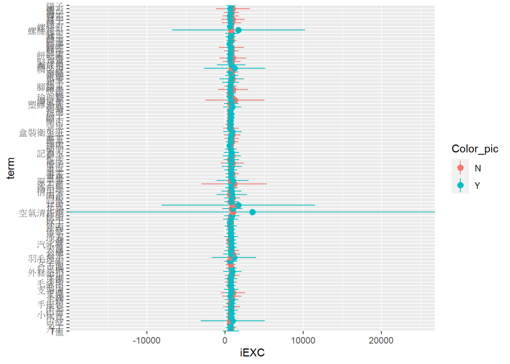

```r
i_RT_tb <- df_norm %>%
  filter(correct==1) %>%
  group_by(term, Design, Color_pic) %>%
  summarise(iEXC = mean(response_time), iVER = qnorm(.975)*sd(response_time)) # summarise the confidence intervals by item per color

i_RT_tb %>% ggplot(aes(y=term,x=iEXC,xmin=iEXC-iVER, xmax=iEXC+iVER, color = Color_pic)) +
  geom_pointrange() +
  coord_cartesian(expand = FALSE) # Illustrate the ranges of item RT
```

```r
ggsave(filename = "item_comparision.png")
```

## Exclude strange items

```r
strange_items <- c("空氣清新劑","外套鈕扣","牙刷","螺絲起子","被子","網球拍","小提琴","吉他")
df_norm_excluded <- df_norm %>% filter(!(term %in% strange_items))
```

## Analytic table after excluded strange items

Based on the filtered items, we build the tables for by-participant and by-item t-tests.

Summary by participants

| Design | Color_pic | N | mRT | SD |
| --- | --- | --- | --- | --- |
| Critical | N | 26 | 732.5274 | 126.6154 |
| Critical | Y | 26 | 757.7736 | 179.7197 |
| Filler | N | 26 | 844.6541 | 174.5838 |
| Filler | Y | 26 | 802.2026 | 185.2411 |

| Design | Color_pic | N | Accuracy | SD |
| --- | --- | --- | --- | --- |
| Critical | N | 26 | 0.8946886 | 0.0602990 |
| Critical | Y | 26 | 0.8791209 | 0.0862215 |
| Filler | N | 26 | 0.9222222 | 0.0659966 |
| Filler | Y | 26 | 0.9324786 | 0.0527677 |

Critical pictures and filler pictures had unequal response times between color version and blank version. Participants’ accuracy were lower for critical pictures.

Summary by items

| Design | Color_pic | N | mRT | SD |
| --- | --- | --- | --- | --- |
| Critical | N | 42 | 738.7493 | 123.8708 |
| Critical | Y | 42 | 760.0974 | 128.9580 |
| Filler | N | 44 | 848.8802 | 112.6226 |
| Filler | Y | 44 | 806.7768 | 159.6798 |

| Design | Color_pic | N | Accuracy | SD |
| --- | --- | --- | --- | --- |
| Critical | N | 42 | 0.8946886 | 0.0700800 |
| Critical | Y | 42 | 0.8791209 | 0.0638923 |
| Filler | N | 44 | 0.9213287 | 0.0580369 |
| Filler | Y | 44 | 0.9331294 | 0.0508779 |

## Rerun T-tests by condition and by measurement

```r
## by-participant RT analysis
result_p_Critical_RT <- t.test(pRT ~ Color_pic,
       paired = TRUE,
       data=subset(p_RT,Design=="Critical"),
       alternative = "less") %>%
  tidy()

result_p_Filler_RT <- t.test(pRT ~ Color_pic,
       paired = TRUE,
       data=subset(p_RT,Design=="Filler"),
       alternative = "less") %>%
  tidy()

## by-item RT analysis
result_i_Critical_RT <- t.test(iRT ~ Color_pic,
       paired = TRUE,
       data=subset(i_RT,Design=="Critical"),
       alternative = "less") %>%
  tidy()

result_i_Filler_RT <- t.test(iRT ~ Color_pic,
       paired = TRUE,
       data=subset(i_RT,Design=="Filler"),
       alternative = "less") %>%
  tidy()


## by-participant Accuracy analysis
result_p_Critical_Acc <- t.test(Acc ~ Color_pic,
       paired = TRUE,
       data=subset(p_Acc,Design=="Critical"),
       alternative = "less") %>%
  tidy()

result_p_Filler_Acc <- t.test(Acc ~ Color_pic,
       paired = TRUE,
       data=subset(p_Acc,Design=="Filler"),
       alternative = "less") %>%
  tidy()

## by-item Accuracy analysis
result_i_Critical_Acc <- t.test(Acc ~ Color_pic,
       paired = TRUE,
       data=subset(i_Acc,Design=="Critical"),
       alternative = "less") %>%
  tidy()

result_i_Filler_Acc <- t.test(Acc ~ Color_pic,
       paired = TRUE,
       data=subset(i_Acc,Design=="Filler"),
       alternative = "less") %>%
  tidy()
```

> A paired-samples t test found no significant color advantage for experimental items: by the response times, $t_1$(25) = -1.01, *p* = 0.161; $t_2$(41) = -0.82, *p* = 0.207, and by the accuracy, $t_1$(25) = 1.12, *p* = 0.864; $t_2$(41) = 1.3, *p* = 0.9. Another paired-samples t test found no significant color advantage for filler items: by the response times, $t_1$(25) = 1.19, *p* = 0.877; $t_2$(43) = 1.57, *p* = 0.938, and by the accuracy, $t_1$(25) = -0.79, *p* = 0.219; $t_2$(43) = -0.96, *p* = 0.172.

**Warning** This analysis excluded 8 items: 空氣清新劑, 外套鈕扣, 牙刷, 螺絲起子, 被子, 網球拍, 小提琴, 吉他.